# Chapter 6 will use the standard Normal Distribution curve. You will be constructing 90%, 95%, and 97% confidence intervals.

### Go look up those P-values and Z-scores in the table below:

| Z | 0.00 | 0.01 | 0.02 | 0.03 | 0.04 | 0.05 | 0.06 | 0.07 | 0.08 | 0.09 |
| --- | --- | --- | --- | --- | --- | --- | --- | --- | --- | --- |
| 0.0 | 0.0000 | 0.0040 | 0.0080 | 0.0120 | 0.0160 | 0.0199 | 0.0239 | 0.0279 | 0.0319 | 0.0359 |
| 0.1 | 0.0398 | 0.0438 | 0.0478 | 0.0517 | 0.0557 | 0.0596 | 0.0636 | 0.0675 | 0.0714 | 0.0753 |
| 0.2 | 0.0793 | 0.0832 | 0.0871 | 0.0910 | 0.0948 | 0.0987 | 0.1026 | 0.1064 | 0.1103 | 0.1141 |
| 0.3 | 0.1179 | 0.1217 | 0.1255 | 0.1293 | 0.1331 | 0.1368 | 0.1406 | 0.1443 | 0.1480 | 0.1517 |
| 0.4 | 0.1554 | 0.1591 | 0.1628 | 0.1664 | 0.1700 | 0.1736 | 0.1772 | 0.1808 | 0.1844 | 0.1879 |
| 0.5 | 0.1915 | 0.1950 | 0.1985 | 0.2019 | 0.2054 | 0.2088 | 0.2123 | 0.2157 | 0.2190 | 0.2224 |
| 0.6 | 0.2257 | 0.2291 | 0.2324 | 0.2357 | 0.2389 | 0.2422 | 0.2454 | 0.2486 | 0.2517 | 0.2549 |
| 0.7 | 0.2580 | 0.2611 | 0.2642 | 0.2673 | 0.2704 | 0.2734 | 0.2764 | 0.2794 | 0.2823 | 0.2852 |
| 0.8 | 0.2881 | 0.2910 | 0.2939 | 0.2967 | 0.2995 | 0.3023 | 0.3051 | 0.3078 | 0.3106 | 0.3133 |
| 0.9 | 0.3159 | 0.3186 | 0.3212 | 0.3238 | 0.3264 | 0.3289 | 0.3315 | 0.3340 | 0.3365 | 0.3389 |
| 1.0 | 0.3413 | 0.3438 | 0.3461 | 0.3485 | 0.3508 | 0.3531 | 0.3554 | 0.3577 | 0.3599 | 0.3621 |
| 1.1 | 0.3643 | 0.3665 | 0.3686 | 0.3708 | 0.3729 | 0.3749 | 0.3770 | 0.3790 | 0.3810 | 0.3830 |
| 1.2 | 0.3849 | 0.3869 | 0.3888 | 0.3907 | 0.3925 | 0.3944 | 0.3962 | 0.3980 | 0.3997 | 0.4015 |
| 1.3 | 0.4032 | 0.4049 | 0.4066 | 0.4082 | 0.4099 | 0.4115 | 0.4131 | 0.4147 | 0.4162 | 0.4177 |
| 1.4 | 0.4192 | 0.4207 | 0.4222 | 0.4236 | 0.4251 | 0.4265 | 0.4279 | 0.4292 | 0.4306 | 0.4319 |
| 1.5 | 0.4332 | 0.4345 | 0.4357 | 0.4370 | 0.4382 | 0.4394 | 0.4406 | 0.4418 | 0.4429 | 0.4441 |
| 1.6 | 0.4452 | 0.4463 | 0.4474 | 0.4484 | 0.4495 | 0.4505 | 0.4515 | 0.4525 | 0.4535 | 0.4545 |
| 1.7 | 0.4554 | 0.4564 | 0.4573 | 0.4582 | 0.4591 | 0.4599 | 0.4608 | 0.4616 | 0.4625 | 0.4633 |
| 1.8 | 0.4641 | 0.4649 | 0.4656 | 0.4664 | 0.4671 | 0.4678 | 0.4686 | 0.4693 | 0.4699 | 0.4706 |
| 1.9 | 0.4713 | 0.4719 | 0.4726 | 0.4732 | 0.4738 | 0.4744 | 0.4750 | 0.4756 | 0.4761 | 0.4767 |
| 2.0 | 0.4772 | 0.4778 | 0.4783 | 0.4788 | 0.4793 | 0.4798 | 0.4803 | 0.4808 | 0.4812 | 0.4817 |
| 2.1 | 0.4821 | 0.4826 | 0.4830 | 0.4834 | 0.4838 | 0.4842 | 0.4846 | 0.4850 | 0.4854 | 0.4857 |
| 2.2 | 0.4861 | 0.4864 | 0.4868 | 0.4871 | 0.4875 | 0.4878 | 0.4881 | 0.4884 | 0.4887 | 0.4890 |
| 2.3 | 0.4893 | 0.4896 | 0.4898 | 0.4901 | 0.4904 | 0.4906 | 0.4909 | 0.4911 | 0.4913 | 0.4916 |
| 2.4 | 0.4918 | 0.4920 | 0.4922 | 0.4925 | 0.4927 | 0.4929 | 0.4931 | 0.4932 | 0.4934 | 0.4936 |
| 2.5 | 0.4938 | 0.4940 | 0.4941 | 0.4943 | 0.4945 | 0.4946 | 0.4948 | 0.4949 | 0.4951 | 0.4952 |
| 2.6 | 0.4953 | 0.4955 | 0.4956 | 0.4957 | 0.4959 | 0.4960 | 0.4961 | 0.4962 | 0.4963 | 0.4964 |
| 2.7 | 0.4965 | 0.4966 | 0.4967 | 0.4968 | 0.4969 | 0.4970 | 0.4971 | 0.4972 | 0.4973 | 0.4974 |
| 2.8 | 0.4974 | 0.4975 | 0.4976 | 0.4977 | 0.4977 | 0.4978 | 0.4979 | 0.4979 | 0.4980 | 0.4981 |
| 2.9 | 0.4981 | 0.4982 | 0.4982 | 0.4983 | 0.4984 | 0.4984 | 0.4985 | 0.4985 | 0.4986 | 0.4986 |
| 3.0 | 0.4987 | 0.4987 | 0.4987 | 0.4988 | 0.4988 | 0.4989 | 0.4989 | 0.4989 | 0.4990 | 0.4990 |

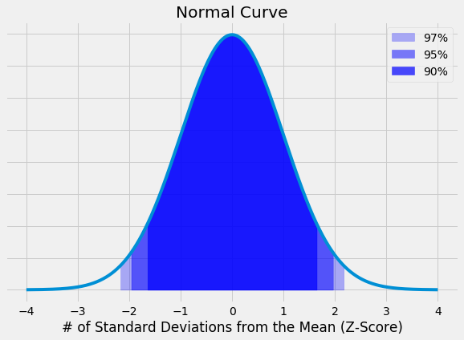

### Step 1: Find your variables.

- The mean $\bar{x}$
- The standard deviation $s$
- And the number of observations $n$

### Step 2: Using the given confidence level, find your Z-scores.

- These were given and explained above.

### Step 3: Construct your confidence interval using the following equation.

$$\bar{X}\pm Z \frac{S}{\sqrt n}$$

## Problem 6.

A sample consists of 75 food processors purchased several years ago. The replacement times of those processors have a mean of 8.2 years and standard deviation of 1.1 years. COnstruct a 90% confidence interval for the mean replacement time of all the food processors from that time.

- The mean $\bar{x}\ =\ 8.2\ years$
- The standard deviation $s\ =\ 1.1\ years$
- And the number of observations $n\ =\ 75\ food\ processors$

#### Confidence level: 90%

#### Z-scores: $\pm1.64$

### Confidence Interval: $$8.2\ \pm\ 1.64\frac{1.1}{\sqrt 75}\ =\ [8.0 < \mu < 8.4]$$

### We are 90% confident that the true population mean $\mu$ of food processor replacement times is between 8.0 years and 8.4 years.

## Problem 7.

A psychologist developed a new test of spatial perception and she wants to estimate the mean score achieved by male pilots. How many people must she test if she wants the sample mean to be in error by no more than 2.0 points with 95% confidence?

#### When determining how large a sample size you need, always round up. You cannot have 0.5 of a person and you don't want an error larger than the desired amount.

- The mean $\bar{x}\ not\ needed$
- The standard deviation $s\ =\ unknown$
- And the number of observations $n\ =\ unknown$

### The answer key says $n\ =\ 432$ but there is no $s$ in the question to find $n$.

# Proportions

## These are very different than the other confidence intervals.

## The idea is that you will use probabilities and known equations to construct confidence intervals.

$$sample\ proportion\ \hat{p}\pm Z \sqrt{\frac{\hat{p}(1-\hat{p})}{n}}$$

### $p$ is the true mean proportion

### $\hat{p}$ is the sample proportion (true cases)

### $(1-\hat{p})$ are the (false cases)

## Problem 8.

It was found that out of 800 people tested, 600 had normal blood pressure. Using 95% confidence, construct the interval estimate of the sample population proportion of people with normal blood pressure.

- Sample size $n$ = 800
- Normal blood pressure $\hat{p}=\frac{600}{800}=\frac{3}{4}=0.75$
- Not normal blood pressure $(1-\hat{p})=\frac{200}{800}=\frac{1}{4}=0.25$

### Confidence level: 95%

### Z-score: 1.96

$$0.75\pm1.96\sqrt{\frac{0.75*0.25}{800}}=0.75\pm0.03\ meaning\ [0.720<p<0.780]$$

## We are 95% confident that the true proportion of people with normal blood pressure is between 72% and 78%.

## Problem 9.

Find minimum sample size required to estimate a population proportion with a margin of error of 2% and a confidence level of 97%; sample proportion from the previous study is estimated to be 0.85.

- Sample size $n$ = unknown
- True Cases $\hat{p}=0.85$
- False Cases $(1-\hat{p})=0.15$

### Confidence level: 97%

### Z-score: 2.17

$$Error=2.17\sqrt{\frac{0.85*0.15}{n}}=0.02$$

Multiply 0.85 and 0.15 $$2.17\sqrt{\frac{0.1275}{n}}=0.02$$ Divide both sides by the Z-score $$\sqrt{\frac{0.1275}{n}}=\frac{0.02}{2.17}$$ Square both sides $$\frac{0.1275}{n}={(\frac{0.02}{2.17})}^2$$ Invert both sides by raising to the power of -1 $${(\frac{0.1275}{n})}^{-1}={(\frac{0.02}{2.17})}^{-2}=\frac{n}{0.1275}={(\frac{2.17}{0.02})}^{2}$$ Multiply both sides by $\hat{p}(1-\hat{p})$ $$n={(\frac{2.17}{0.02})}^{2}*0.1275=1501\ people$$

## The minimum sample size required to estimate a population proportion with a margin of error of 2% and a 97% confidence level is 1501.

# Problem 10

$$n=65\ one-ounce\ samples$$

$$H_{0} = null\ hypothesis$$$$H_{1} = alternative\ hypothesis$$$$alpha=\alpha=0.01$$

In the answer key, the variable $Zc$ is the critical value, aka the Z-score we are comparing against. In our case, the alpha value $\alpha=0.01$ so the $Zc$ we are finding is the Z-score of $\pm2.57$. Notice the $\pm$ because we are doing a 2-tailed test.

$$H_{0}:\ \mu=600mg$$$$H_{1}:\ \mu\ne600mg$$

$$sample\ mean=\bar x=589mg$$$$sample\ standard\ deviation=\frac{s}{\sqrt{n}}=\frac{21mg}{\sqrt{65}}=2.605mg$$

$$Z-score=\frac{\bar{x}-\mu}{\sigma}=\frac{589-600}{2.605}=-4.223$$

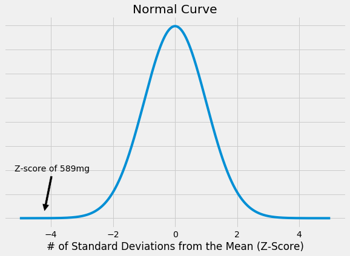

### The P-value of our Z-score is extremely low.

### I guarantee you cannot find 4.223 on your Z-table.

### You should treat it as 0.

### Our alpha value is 0.01

$$alpha=\alpha=0.01$$

### If our $\alpha$ > P-value, we reject the null hypothesis, $H_{0}$.

$$P-value\ of\ 0<\alpha\ value\ of\ 0.01$$

### The way this was taught to me:

### If our fish, $\alpha$ is bigger than our pond, P-value, then we reject.

### Else, we fail to reject the null hypothesis, $H_{0}$. We don't accept the alternative hypothesis, $H_{1}$, we just fail to reject $H_{0}$.

# Problem 11

$$H_{0}: p < 5.8\%$$$$H_{1}: p \ge 5.8\%$$$$alpha=\alpha=0.01$$

### Notice this is a 1-tailed test with the $<\ and\ \ge$ symbols. Our critical value $Zc$ will be on your table as 2.33 because we are only chopping off the lowest 1%, NOT the 1% from each side.

$$P-value\ on\ Z-table\ =\ 0.4901$$$$Z-score\ of\ -2.33$$

### Z-score is negative because we're testing the left side of the normal curve.

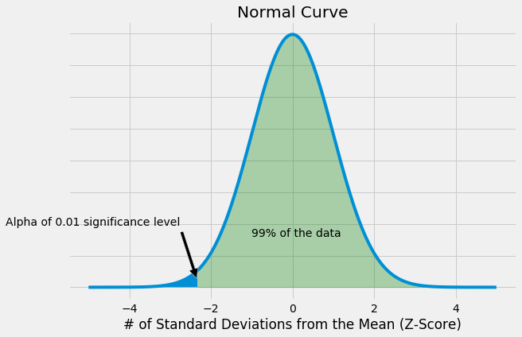

$$n=1520$$

$$sample\ \bar p=\frac{58}{1520}=0.03816=3.816\%$$

$$\sigma_{H_{0}} = \sqrt{p*(1-p)} = \sqrt{0.058 * (1-0.058)}=0.2337$$

### The P-value of our Z-score is extremely low.

### I guarantee you cannot find 3.31 on your Z-table.

### You should treat the P-value as 0.

### Our alpha value is 0.01

$$alpha=\alpha=0.01$$

### If our $\alpha$ > P-value, we reject the null hypothesis, $H_{0}$.

$$P-value\ of\ 0<\alpha\ value\ of\ 0.01$$

### The way this was taught to me:

### If our fish, $\alpha$ is bigger than our pond, P-value, then we reject.

### Else, we fail to reject the null hypothesis, $H_{0}$. We don't accept the alternative hypothesis, $H_{1}$, we just fail to reject $H_{0}$.